# BE 5210: Homework 1

Spring 2026 | 33 points

**Due:** Thursday, 01/29/2026 10:00 PM

**Objective:** Working with the Pennsieve platform to explore different neural signals.

### Save Pennsive configuration file for future use

```python
# Install Pennsieve
!wget https://github.com/Pennsieve/pennsieve-agent/releases/download/1.8.10/pennsieve_1.8.10_amd64.deb
!dpkg -i pennsieve_1.8.10_amd64.deb
!apt-get install -f
!rm pennsieve_1.8.10_amd64.deb
!pip install pennsieve
```

[output not shown]

For the first time logging in, please run the cell below and enter the following content when prompted (same as you did in Homework 0):

- Profile name [user] = FIRSTNAME LASTNAME
- API token: YOUR API KEY
- API secret: YOUR API SECRET

This will generate a config file under /root/.pennsieve/config.ini.

To avoid entring credentials each time, please download this config file and keep it for future use.

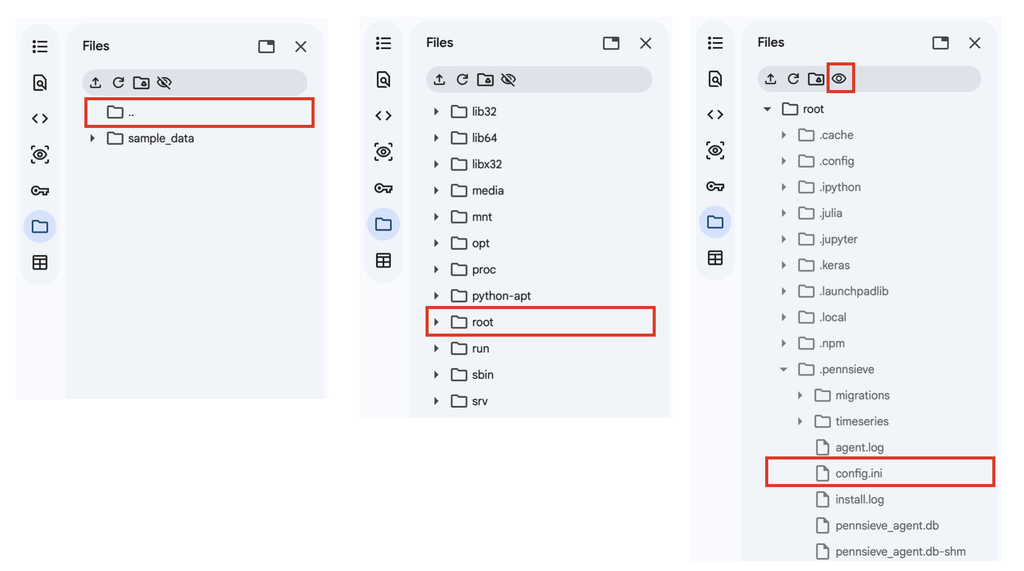

For future homework assignments, after installing Pennsieve, you can skip entering credentials by uploading the saved config.ini file to the same location: /root/.pennsieve/config.ini. You may need to enable hidden files (eyeball icon, pictured above).

```python
# Please uncomment the config code below or upload the config.ini file to /root/.pennsieve
!pennsieve config wizard
```

```
Existing configuration file found at: /root/.pennsieve/config.ini

Would you like to overwrite your existing configuration? (y/n): n
```

```python
# Basic imports and an updated PennsieveStreamer class are provided here
# Please read through the class definition to understand how to use it
# or ask an LLM to explain it to you

%env PENNSIEVE_AGENT_PORT=9002
!pennsieve agent

import os
import sys
import matplotlib
import pandas as pd
import numpy as np
from scipy import signal as sig
from contextlib import contextmanager
from IPython.display import Image
import matplotlib.pyplot as plt
from pennsieve import Pennsieve

class PennsieveStreamer:
    """
    A simplified interface for streaming data from Pennsieve.
    """
    def __init__(self, target_port='localhost:9002'):
        """
        Initialize the connection to the Pennsieve Agent.

        Args:
            target_port (str): The address of the local Pennsieve Agent (default: localhost:9002).
        """
        self.ps = None
        self.dataset = None

        try:
            print(f"Connecting to Pennsieve Agent at {target_port}...")

            @contextmanager
            def suppress_stdout():
                with open(os.devnull, "w") as devnull:
                    old_stdout = sys.stdout
                    sys.stdout = devnull
                    try:
                        yield
                    finally:
                        sys.stdout = old_stdout

            with suppress_stdout():
                self.ps = Pennsieve(target=target_port)

            print("Successfully connected to Pennsieve Agent.")
        except Exception as e:
            print(f"Failed to connect to Pennsieve Agent: {e}")
            print("Ensure the Pennsieve Agent is running (run 'pennsieve agent' in terminal).")
            raise e

    def set_dataset(self, dataset_id: str):
        """
        Set the active dataset by ID or dataset name. Resolves the ID to a name if necessary.

        Args:
            dataset_id (str): The Pennsieve Dataset ID (e.g., 'N:dataset:...').
        """
        print(f"Resolving dataset ID: {dataset_id}")
        datasets_dict = self.ps.get_datasets()

        found_name = None
        if isinstance(datasets_dict, dict):
            for name, id_val in datasets_dict.items():
                if id_val == dataset_id or name == dataset_id:
                    print(f"Found dataset: '{name}'")
                    found_name = name
                    break

        if not found_name:
             raise ValueError(f"Dataset with ID {dataset_id} not found in available datasets.")

        target = found_name

        try:
            self.ps.use_dataset(target)
            self.dataset = self.ps.dataset
            print(f"Active dataset set to: {target}")

        except Exception as e:
            print(f"Error setting dataset: {e}")
            raise e

    def map_package_id(self, package_name: str) -> str:
        """
        Map a package name to its ID.

        Args:
            package_name (str): The name of the package.

        Returns:
            str: The ID of the package.
        """
        packages = self.ps.get(f"https://api.pennsieve.io/datasets/{self.ps.dataset}/packages?filename={package_name}.edf",params={"accept": "*/*"})['packages']
        packages = [p['content'] for p in packages if p['content']['state'] == 'READY' ]
        if len(packages) > 1:
            raise ValueError("Multiple packages with the same name identified. Please use package ID instead.")
        package_id = packages[0]['nodeId']
        return package_id

    def set_package(self, package_id: str):
        """
        Set the active dataset by ID or dataset name. Resolves the ID to a name if necessary.

        Args:
            package_id (str): The Pennsieve Package ID (e.g., 'N:package:...').
        """
        if not self.dataset:
            raise ValueError("Dataset not set. Call set_dataset() first.")

        # map package name to ids
        if not package_id.startswith('N:package'):
            package_id = self.map_package_id(package_id)
        self.package_id = package_id
        print(f"Active package set to: {package_id}")

    def get_clip(self, start_sec: float, end_sec: float, channel_list: list = None, relative_time = True) -> pd.DataFrame:
        """
        Stream a data clip for all channels in a package.

        Args:
            package_id (str): The ID of the TimeSeries package (file).
            start_sec (float): Start time in seconds relative to recording start.
            end_sec (float): End time in seconds relative to recording start.

        Returns:
            pd.DataFrame: A DataFrame containing the streamed data.
        """
        if not self.package_id:
            raise ValueError("Package not set. Call set_package() first.")

        # Get channels to get IDs
        channels = self.ps.timeseries.getChannels(self.dataset, self.package_id, True)

        if not channels:
            print("No channels found in this package.")
            return pd.DataFrame()

        if channel_list is None:
            channel_ids = [c.id for c in channels]
            channel_names = [c.name for c in channels]
        else:
            channel_ids = [c.id for c in channels if c.name in channel_list]
            channel_names = [c.name for c in channels if c.name in channel_list]

            if not channel_ids:
                print("No matching channels found in this package.")
                return pd.DataFrame()

        data = self.ps.timeseries.getRangeForChannels(
            self.dataset,
            self.package_id,
            channel_ids,
            start_sec,
            end_sec,
            False, # force_refresh
            True   # is_relative_time
        )
        data.columns = channel_names
        data = data.sort_index()
        if relative_time:
            ts = self.get_ts_details_from_name(channel_names[0])
            data.index = data.index - ts['start_time']
        return data

    def get_metadata(self) -> dict:
        """
        Retrieve metadata for the package (channels, rates, units).

        Args:
            package_id (str): The ID of the TimeSeries package.

        Returns:
            dict: Metadata including channel count and details (rate, unit, range).
        """
        if not self.package_id:
            raise ValueError("Package not set. Call set_package() first.")

        channels = self.ps.timeseries.getChannels(self.dataset, self.package_id, True) # include_data=True

        metadata = {
            "channel_count": len(channels),
            "channels": []
        }

        for c in channels:
            channel_info = {
                "name": getattr(c, 'name', 'Unknown'),
                "id": getattr(c, 'id', 'Unknown'),
                "rate_hz": getattr(c, 'rate', None),
                "unit": getattr(c, 'unit', None),
                "start_time": getattr(c, 'start_time', None),
                "end_time": getattr(c, 'end_time', None)
            }
            metadata["channels"].append(channel_info)

        return metadata

    def get_channel_labels(self) -> list:
        """
        Get a list of channel labels for a specific package.

        Args:
            package_id (str): The ID of the TimeSeries package.

        Returns:
            list: A list of channel labels.
        """
        if not self.package_id:
            raise ValueError("Package not set. Call set_package() first.")

        channels = self.ps.timeseries.getChannels(self.dataset, self.package_id, True) # include_data=True
        return [c.name for c in channels]

    def get_channel_indices(self, channel_list: list) -> list:
        """
        Get a list of channel labels for a specific package.

        Args:
            package_id (str): The ID of the TimeSeries package.

        Returns:
            list: A list of channel labels.
        """
        if not self.package_id:
            raise ValueError("Package not set. Call set_package() first.")

        channels = self.ps.timeseries.getChannels(self.dataset, self.package_id, True) # include_data=True
        channel_indices = []
        for e, c in enumerate(channels):
            if c.name in channel_list:
                channel_indices.append(e)
        return channel_indices

    def get_ts_details_from_name(self, channel_name: str) -> dict:
        """
        Get details about a specific channel in a TimeSeries package.

        Args:
            package_id (str): The ID of the TimeSeries package.
            channel_name (str): The name of the channel to retrieve details for.

        Returns:
            dict: Details about the specified channel, including rate, unit,
                  start time, and end time.
        """
        if not self.package_id:
            raise ValueError("Package not set. Call set_package() first.")

        channels = self.ps.timeseries.getChannels(self.dataset, self.package_id, True) # include_data=True
        if not channels:
            print("No channels found in this package.")
            return {}
        if channel_name not in [c.name for c in channels]:
            print(f"Channel '{channel_name}' not found in this package.")
            return {}
        indice = self.get_channel_indices([channel_name])[0]
        c = channels[indice]
        channel_info = {
              "name": getattr(c, 'name', 'Unknown'),
              "id": getattr(c, 'id', 'Unknown'),
              "rate_hz": getattr(c, 'rate', None),
              "unit": getattr(c, 'unit', None),
              "start_time": getattr(c, 'start_time', None),
              "end_time": getattr(c, 'end_time', None),
        }
        channel_info['duration'] = channel_info['end_time'] - channel_info['start_time']

        return channel_info

    def get_ts_details_from_indice(self, channel_indice: str) -> dict:
        """
        Get details about a specific channel in a TimeSeries package.

        Args:
            package_id (str): The ID of the TimeSeries package.
            channel_name (str): The name of the channel to retrieve details for.

        Returns:
            dict: Details about the specified channel, including rate, unit,
                  start time, and end time.
        """
        if not self.package_id:
            raise ValueError("Package not set. Call set_package() first.")

        channels = self.ps.timeseries.getChannels(self.dataset, self.package_id, True) # include_data=True
        c = channels[channel_indice]
        channel_info = {
              "name": getattr(c, 'name', 'Unknown'),
              "id": getattr(c, 'id', 'Unknown'),
              "rate_hz": getattr(c, 'rate', None),
              "unit": getattr(c, 'unit', None),
              "start_time": getattr(c, 'start_time', None),
              "end_time": getattr(c, 'end_time', None),
        }
        channel_info['duration'] = channel_info['end_time'] - channel_info['start_time']

        return channel_info

    def get_annotations(self):
        """
        Get annotations for a specific package.

        Args:
            package_id (str): The ID of the TimeSeries package.

        Returns:
            list: A list of annotations.
        """
        if not self.package_id:
            raise ValueError("Package not set. Call set_package() first.")

        annots = self.ps.get(f"https://api.pennsieve.io/packages/{self.package_id}/annotations",params={"accept": "*/*"})['annotations']

        return annots
```

```
env: PENNSIEVE_AGENT_PORT=9002
Pennsieve Agent is already running on port: 9002
```

## 1. Seizure Activity (16 pts)

The dataset I521_A0001_D002 contains an example of human intracranial EEG (iEEG) data displaying seizure activity. It is recorded from a single channel (2 electrode contacts) implanted in the hippocampus of a patient with temporal lobe epilepsy being evaluated for surgery. In these patients, brain tissue where seizures are seen is often resected.

Below, you will do multiple comparisons with this iEEG data and the unit activity that you worked with in Homework 0 (I521_A0001_D001). You will need to refer to that homework and/or dataset to help answer these questions.

### 1

Retrieve the dataset using the PennsieveStreamer. What is the sampling rate of this data? What is the maximum frequency of the signal content that we can resolve? (2 pts)

```python
# Your code here
streamer = PennsieveStreamer()

DATASET_ID = 'N:dataset:cf2376f0-aede-4c3c-b6a7-0cefded0d64c'
FILE_ID = 'N:package:78d0a7d5-ef6d-4775-b280-c52a9a73c36e'

streamer.set_dataset(DATASET_ID)
streamer.set_package(FILE_ID)
streamer.get_metadata()
```

```
Connecting to Pennsieve Agent at localhost:9002...
Successfully connected to Pennsieve Agent.
Resolving dataset ID: N:dataset:cf2376f0-aede-4c3c-b6a7-0cefded0d64c
Found dataset: 'Homework Data'
Active dataset set to: Homework Data
Active package set to: N:package:78d0a7d5-ef6d-4775-b280-c52a9a73c36e
```

```
{'channel_count': 1,
 'channels': [{'name': 'seizure',
   'id': 'N:channel:d17dab29-682a-4f52-80b8-846e20efe192',
   'rate_hz': 200.0,
   'unit': 'uV',
   'start_time': 473385600000000,
   'end_time': 473386244995000}]}
```

`Sampling rate is 200 Hz, maximum frequency resolvable is then 100 Hz.`

### 2

How does the duration of this recording compare with the recording from HW0 (I521_A0001_D001)? (2 pts)

```python
# Your code here
time_seconds = (streamer.get_metadata()['channels'][0]['end_time'] - streamer.get_metadata()['channels'][0]['start_time']) / 1e6
print(time_seconds)
```

```
644.995
```

`This recording is 644.995 seconds. The recording from HW0 was 10 seconds. This recording is much longer.`

### 3

Provide a plot of the first 500 ms of data from this recording. (2 pts)

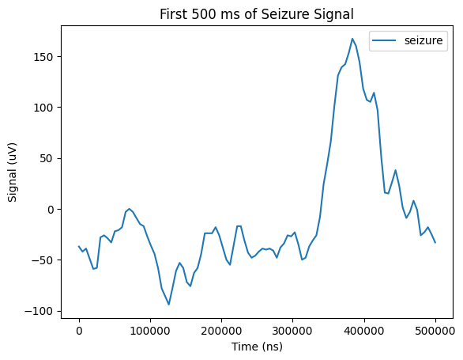

```python
# Your code here
data = streamer.get_clip(0, 0.5)

data.plot()
plt.title('First 500 ms of Seizure Signal')
plt.xlabel('Time (ns)')
plt.ylabel('Signal (uV)')
plt.show()
```

### 4

Compare the activity in this sample with the data from HW0. What differences do you notice in the amplitude and frequency characteristics? (2 pts)

```python
# Your code here
data = streamer.get_clip(0, 645)
data = abs(data)
average_amplitude = data.mean()
print(average_amplitude)
```

```
seizure    146.549114
dtype: float64
```

`The most clear signal difference is the amplitude. The HW0 dataset range is closer to 20 µV, while the average amplitude of the HW1 dataset is around 150 µV.`

`In terms of frequency, it seems that the frequency is lower in the HW1 dataset. The frequency increases in the HW1 dataset upon what I'd assume to be the seizure starting, while the frequency in the HW0 dataset seems relatively constant. However, this also is related to the much higher sampling rate in the HW0 dataset which adds a lot of high frequency noise which makes the HW1 dataset appear to have a much lower frequency.`

### 5

The unit activity sample in (I521_A0001_D001) was high-pass filtered to remove low-frequency content. Assume that the seizure activity in (I521_A0001_D002) has not been high-pass filtered. Given that the power of a frequency band scales roughly as $1/f$, how might these differences in preprocessing contribute to the differences you noted in the previous question? (There is no need to get into specific calculations here. We just want general ideas.) (3 pts)

`Given that power scales as 1/f and the HW0 dataset was high-pass filtered, I'd expect that the first dataset has lower power since the low frequency signal (with higher power) was filtered out. The lack of that process in the HW1 dataset explains why we observed a higher average amplitude in that dataset compared to the HW0 one.`

`In terms of frequency, the observed high frequency signal in the HW0 dataset is then explained by this filter. Obviously no low frequency signal is seen if that signal was filtered out. Also, this may explain why we see a lower frequency signal in the HW1 dataset, which is just that the high frequency signal is lower in power and goes undetected upon visualization compared to the lower frequency signal.`

### 6

Two common methods of human iEEG are known as electrocorticography (ECoG) and stereoelectroencephalography (SEEG). For one of these paradigms (please indicate which you choose), find and report at least two of the following electrode characteristics: shape, material, size. Please note that exact numbers aren't required, but please cite any sources used. (3 pts)

`ECoG sensors look like small flat circles. They are often placed in a grid, from 8 by 8 to 1 by 4 [https://advanced.onlinelibrary.wiley.com/doi/10.1002/admt.202301692, Figure 3].`

`ECoG sensors are quite small, the thickness of an array is 0.7 mm, and each metal electrode is between 3 and 6 mm. Within the grid, they might be spaced out about 5 to 15 mm. [https://advanced.onlinelibrary.wiley.com/doi/10.1002/admt.202301692, Figure 3]`

### 7

What is a local field potential? How might the characteristics of human iEEG electrodes cause them to record local field potentials as opposed to multiunit activity? Multiunit activity was featured in HW0, recorded from 40-micron Pt-Ir microwire electrodes. (2 pts)

`Local field potentials are a type of signal at a level slightly above the level of a single neuronal electrical spike. Specifically, it aggregates the sum of a bunch of electrical impulses in a "local field."`

`One characteristic that might be disadvantageous is the larger size of ECoG sensors. Speicifically, they have 3-6 mm electrodes, which is much bigger than the 40 micron electrodes. I suspect that larger electrodes result in capturing local field potentials just because the larger size isn't precise enough to capture at the granularity of multiunit activity.`

## 2. Evoked Potentials (17 pts)

The data in I521 A0001 D003 contains an example of a very common type of experiment and neuronal signal, the evoked potential (EP). The data show the response of the whisker barrel cortex region of rat brain to an air puff stimulation of the whiskers. The stim channel shows the stimulation pattern, where the falling edge of the stimulus indicates the start of the air puff, and the rising edge indicates the end. The 'ep' channel shows the corresponding evoked potential. Once again, play around with the data on Pennsieve, in particular paying attention to the effects of stimulation on EPs. You should observe the data with window widths of 60 secs as well as 1 sec. Again, be sure to explore the signal gain to get a more accurate picture. Finally, get a sense for how long the trials are (a constant duration), and how long the entire set of stimuli and responses are.

### 1

Based on your observations, should we use all of the data or omit some of it? (There's no right answer, here, just make your case either way in a few sentences.) (2 pts)

`I do think we should use all the data. Two reasons: First, given that I don't have a strong prior on what to expect, it would be biased for me to omit some of the data for reasons that might not be biologically sound. Second, from my naive eye looking at the signal, it seems pretty consistent and each response by the mouse seems relatively similar. There's some drift in the entire signal's voltage, and the shapes are not all completely identical, but in general there's a common aligned initial reaction to the start of the air puff, followed by a reaction after the air puff ends. Interestingly, some signals show a response right before the air puff, which may be either a flaw or a predicted response. Since it may be a predicted response, that is meaningful and shouldn't be omitted.`

### 2

Retrieve the ep and stim channel data below. What is the average latency (in ms) of the peak response to the stimulus onset over all trials? (Assume stimuli occurs at exactly 1 second intervals.) (3 pts)

```python
# Your code here
streamer2 = PennsieveStreamer()
streamer2.set_dataset("N:dataset:cf2376f0-aede-4c3c-b6a7-0cefded0d64c")
streamer2.set_package("N:package:e76d9ffe-6662-465e-94be-1cf480cd8b75")
streamer2.get_metadata()
```

```
Connecting to Pennsieve Agent at localhost:9002...
Successfully connected to Pennsieve Agent.
Resolving dataset ID: N:dataset:cf2376f0-aede-4c3c-b6a7-0cefded0d64c
Found dataset: 'Homework Data'
Active dataset set to: Homework Data
Active package set to: N:package:e76d9ffe-6662-465e-94be-1cf480cd8b75
```

```
{'channel_count': 2,
 'channels': [{'name': 'stim',
   'id': 'N:channel:33cffe97-4ff5-4b89-a52a-bab9d9d0c007',
   'rate_hz': 2713.0,
   'unit': 'uV',
   'start_time': 473385600000000,
   'end_time': 473385718999631},
  {'name': 'ep',
   'id': 'N:channel:1a413067-c81a-4c75-bf78-05829ccc4577',
   'rate_hz': 2713.0,
   'unit': 'uV',
   'start_time': 473385600000000,
   'end_time': 473385718999631}]}
```

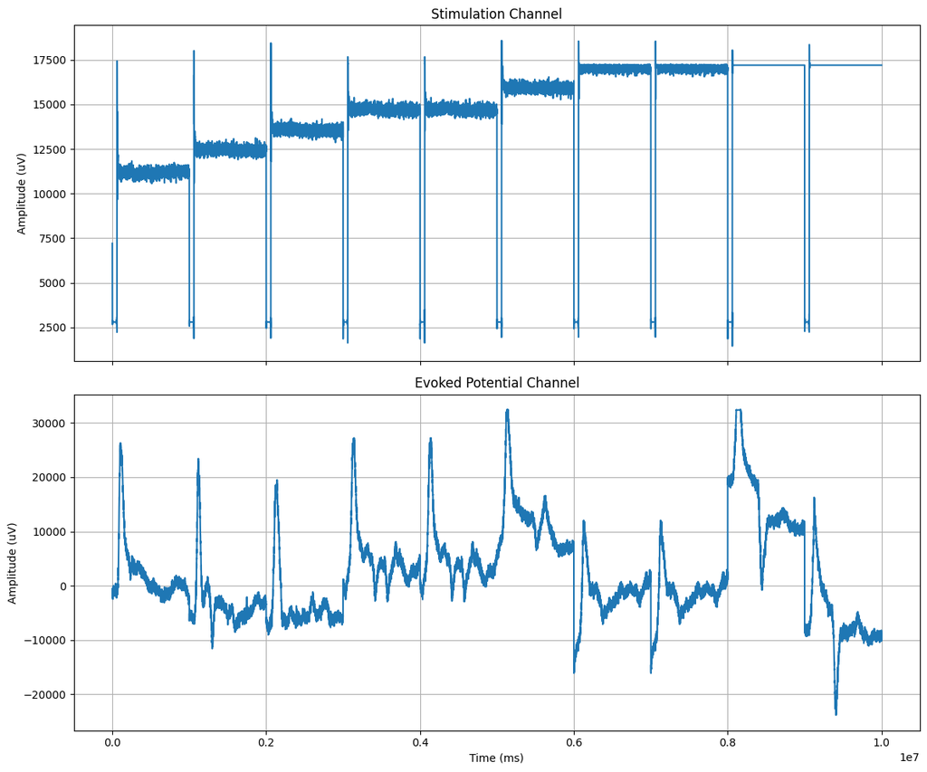

```python
data = streamer2.get_clip(0, 10) # Get some data for plotting

# Plotting the stim and ep channels on separate graphs
fig, axes = plt.subplots(2, 1, figsize=(12, 10), sharex=True)

data['stim'].plot(ax=axes[0])
axes[0].set_title('Stimulation Channel')
axes[0].set_ylabel('Amplitude (uV)')
axes[0].grid(True)

data['ep'].plot(ax=axes[1])
axes[1].set_title('Evoked Potential Channel')
axes[1].set_xlabel('Time (ms)')
axes[1].set_ylabel('Amplitude (uV)')
axes[1].grid(True)

plt.tight_layout()
plt.show()
```

```python
# Find stimulation
# stimulation occurs upon a sudden dropoff in stim signal by over
stimulation = []
def find_stim_index(st):
  # find first label at which signal is below 5000
  for j in st.index:
    if st[j] < 5000:
      stimulation.append(j)
      break

# Find max response
# max response is index of largest magnitude of ep signal in range
response = []
def find_response_index(rp):
  rp = abs(rp)
  # cutoff to just first half to not check for preemptive signal
  rp = rp[:np.median(rp.index)]
  max_index = rp.idxmax()
  response.append(max_index)

# Signal Delay
delay_ms = []
def find_delay():
  delay_ms.append((stimulation[-1] - response[-1]) // -1e3)

from tqdm import tqdm

for i in tqdm(range(118)):
  # print(i)
  data = streamer2.get_clip(i, i+1)
  find_stim_index(data['stim'])
  find_response_index(data['ep'])
  find_delay()

print()
print(np.mean(delay_ms))
```

```
80.83898305084746
```

`The average latency is 80.839 ms`

### 3

In neuroscience, we often need to isolate a small neural signal buried in an appreciable amount of noise. One technique to accomplish this is called the "spike triggered average", sometimes called "signal averaging". This technique assumes that the neural response to a repetitive stimulus is constant (or nearly so), while the noise fluctuates from trial to trial - therefore averaging the evoked response over many trials will isolate the signal and average out the noise. Construct a spike triggered average plot for the data in I521 A0001 D003. Plot the average EP in red. Overlay the standard deviation of the responses in grey. You may find [`plt.fill_between`](https://matplotlib.org/stable/api/_as_gen/matplotlib.pyplot.fill_between.html) and [`np.linspace`](https://numpy.org/doc/stable/reference/generated/numpy.linspace.html) to be helpful. Be sure to include an informative legend. You may also find [this](https://matplotlib.org/stable/gallery/color/named_colors.html) to be helpful for what colors plyplot natively supports (4 pts).

```python
trials = []
for i in tqdm(range(118)):
  data = streamer2.get_clip(i, i+1)
  trials.append(data['ep'].values)
```

```python
import statistics
# Weirdly the signal frequency / sampling size changes during the course of the
# experiment, as such, we just keep signal that is sampled at one specific
# frequency.
most_common_trial_length = statistics.mode(len(trial) for trial in trials)
trials_cropped = [trial for trial in trials if len(trial) == most_common_trial_length]

ep_signal = np.array(trials_cropped)
average_ep = np.mean(ep_signal, axis=0)
std_ep = np.std(ep_signal, axis=0)
```

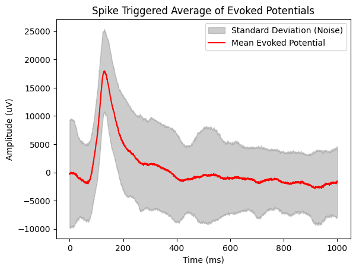

```python
time_axis = np.linspace(0, 1000, ep_signal.shape[1])

plt.fill_between(time_axis, average_ep - std_ep, average_ep + std_ep,
                 color='grey', alpha=0.4, label='Standard Deviation (Noise)')

plt.plot(time_axis, average_ep, color='red', linewidth=1.5, label='Mean Evoked Potential')
plt.title('Spike Triggered Average of Evoked Potentials')
plt.xlabel('Time (ms)')
plt.ylabel('Amplitude (uV)')
plt.legend()
plt.show()
```

### 4.

#### 4a

We often want to get a sense for the amplitude of the noise in a single trial. Propose a method to do this (there are a few reasonably simple methods, so no need to get too complicated). Note: do not assume that the signal averaged EP is the "true" signal and just subtract it from that of each trial, because whatever method you propose should be able to work on the signal from a single trial or from the average of the trials. (4 pts)

`Given we know that the stimulus response is right after the onset of stimulus, one thing we could do is make the assumption that any moduluation in the signal during the 400 to 900 ms part of any one second interval is noise. Then, what I'd do is apply a high pass filter to that section of the data, and take the RMS of that section which should effectively represent the amplitude of the noise.`

#### 4b

Show with a few of the EPs (plots and/or otherwise) that your method gives reasonable results. You may find [`sig.butter`](https://docs.scipy.org/doc/scipy/reference/generated/scipy.signal.butter.html) and [`sig.filtfilt`](https://docs.scipy.org/doc/scipy/reference/generated/scipy.signal.filtfilt.html) helpful. (1 pt)

```python
from collections import Counter
Counter([len(trial) for trial in trials])
```

```
Counter({2713: 49, 4578: 48, 3730: 21})
```

```python
def calculate_noise_amplitude(i):
    no_response_data = get_clip(streamer2, i + 0.4, i + 0.9, ['ep'])
    no_response_data = no_response_data['ep'].values

    # high-pass butterworth filter
    cutoff_freq_hz = 30.0
    nyquist_freq = 0.5 * 2713
    normalized_cutoff_freq = cutoff_freq_hz / nyquist_freq
    b, a = sig.butter(4, normalized_cutoff_freq, btype='high', analog=False)
    filtered_noise_segment = sig.filtfilt(b, a, no_response_data)

    # rms of filtered noise
    rms_noise = np.sqrt(np.mean(filtered_noise_segment**2))

    return rms_noise
```

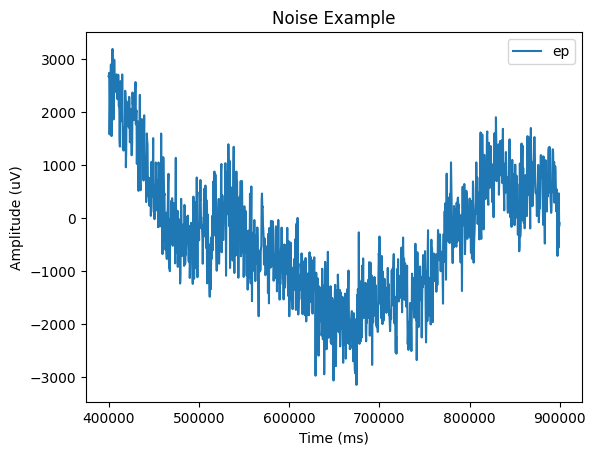

```
Estimated noise level: 476.583624477463
```

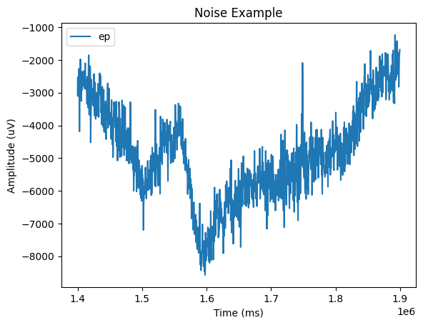

```
Estimated noise level: 487.58019898896384
```

```python
import math
def get_clip(streamer, start_sec: float, end_sec: float, channels=None):
  integer_clip = streamer.get_clip(math.floor(start_sec), math.ceil(end_sec), channels)
  low_index = np.percentile(integer_clip.index, 100 * (start_sec - math.floor(start_sec)))
  high_index = np.percentile(integer_clip.index, 100 - 100 * (math.ceil(end_sec) - end_sec))
  return integer_clip.loc[low_index:high_index]

data = get_clip(streamer2, 0.4, 0.9, ['ep']) # Get some data for plotting
data.plot()
plt.title('Noise Example')
plt.xlabel('Time (ms)')
plt.ylabel('Amplitude (uV)')
plt.show()

print(f"Estimated noise level: {calculate_noise_amplitude(0)}")

data = get_clip(streamer2, 1.4, 1.9, ['ep']) # Get some data for plotting
data.plot()
plt.title('Noise Example')
plt.xlabel('Time (ms)')
plt.ylabel('Amplitude (uV)')
plt.show()

print(f"Estimated noise level: {calculate_noise_amplitude(1)}")
```

`I tried my experiment on the first and second 1-second intervals. The estimated noise levels were around 477 and 488. This seems reasonable, as if we zoom in on the 0.4 to 0.9 second region of those two 1-second intervals (plotted), the peak-to-peak noise difference appears to be around 1000 µV. This would agree with a base to peak amplitude of around 500 µV, which is near what we've found.`

#### 4c

Apply your method on each individual trial and report the mean noise amplitude across all trials. (1 pt)

```python
rms_noises = []

for i in tqdm(range(118)):
    rms_noise = calculate_noise_amplitude(i)
    rms_noises.append(rms_noise)

print()
print(np.mean(rms_noises))
```

```
524.1469559833283
```

`The mean noise amplitude is 524.147 µV.`

#### 4d

Apply your method on the signal averaged EP and report its noise. (1 pt)

```python
import math

# average_ep is the signal averaged ep
# time_axis is the corresponding time in ms

# Build the relevant window
start_idx = np.where(time_axis >= 400)[0][0]
end_idx = np.where(time_axis <= 900)[0][-1]
no_response_data = average_ep[start_idx : end_idx + 1]

# high-pass butterworth filter
cutoff_freq_hz = 30.0
nyquist_freq = 0.5 * 2713
normalized_cutoff_freq = cutoff_freq_hz / nyquist_freq
b, a = sig.butter(4, normalized_cutoff_freq, btype='high', analog=False)
filtered_noise_segment = sig.filtfilt(b, a, no_response_data)

# rms of filtered noise
rms_noise = np.sqrt(np.mean(filtered_noise_segment**2))

rms_noise
```

```
77.36291570557216
```

`77.363 µV`

#### 4e

Do these two values make sense? Explain. (1 pt)